# Individual_Project-Summary

Yinuo (Cathy) Meng

2025-03-29

### This document is an old record of analysis for my individual project in ANGSD 2025 class. (DO NOT USE)

```
### After completing DESeq analysis below, found that I made a mistake in QoRTs alignment QC by using a wron GTF reference file. In addition, even though my STAR-aligned BAM files are good, there is a mistake in my old STAR_align script which leads to failing indexing of the BAM files. For better or…
```

#### Part I: Downloading raw data

**Information of the data:**

——Model system and sample information:

```
This is part of the preliminary data of the RAC1 project in our lab (Rohit Chandwani lab). It is unpublished preliminary data of the lab. It is our alumna, Adrien Grimont, Ph.D., who performed the corresponding experiment. Samples were sent to the genomics core at WCMC for QC and subsequent library …
```

——Cell type:

```
mouse PDAC tumor cell line was used. (mT5 for the data I downloaded now)
This cell line is derived from mouse tumor #5 of the KPC PDAC mouse model (Pft1-Cre, KRAS-G12D, p53-R172H/+ as the mouse genotype)
```

——Treatment and experimental condition:

```
The above data includes two biological replicates for the positive control, two biological replicates for the negative control and two biological replicates for the experimental group: We created the mT5 cell line model, generated shRNAs targeting Kras (2 oligos targeting mouse Kras as 2 positive co…
"mT5_Kras242, mT5_Kras467" ------mT5 + shRNA targeting Kras (positive control)
"mT5_Rac1_11, mT5_Rac1_14": ------mT5 + shRNA targeting Rac1
"mT5_Ren, mT5_Ren2": ------mT5 + shRNA targeting Renilla (negative control)
The treatment is doxycycline. Our shRNA platform is designed for the shRNA expression and activation to be controlled by doxycycline addition. Therefore, we add doxycycline to all cell lines stated above for shRNA to execute its function to deplete targeted proteins and then collected RNA samples fo…
```

——RNA extraction:

```
The RNA was extracted using the phenol extraction methodology. The cell samples were first collected and resuspended in Trizol for lysis purpose. And then chloroform was added and mix to trizol suspensions in order to separate RNA from DNAs, proteins and other cell factors. Then RNA was extracted an…
```

——Library Prep:

```
The genomics core prepared library for us: we applied to use TruSeq RNA Sample Preparation (Non-Stranded and Poly-A selection) method for library prep.
```

——Sequencing platform:

```
Nova-Seq 6000 sequencing platform was used (Illumina). And paired-end sequencing is performed.
```

#### Part II: QC: FASTQC & Multi-QC:

*Set-uPs:*

```bash
# First: Create target directories on cayuga to hold all files
cd /athena/angsd/scratch/yim4002
mkdir Individual_Project/         # Project directory
cd Individual_Project/
mkdir Alignment_dir/              # Directory to hold aligned files
mkdir QC_dir/                     # Directory to hold raw read file QC
mkdir mm10_ref/                   # Directory to contain downloaded reference genome with annotation information
mkdir Raw_data/                   # Directory to contain all raw fastq data
cd Raw_data/
mkdir mT5/                        # Where my raw data files are

# Downloaded and copied all files to the mT5/ directory under Raw_data/ directory
```

*Run fastqc analysis on all fastq files:*

```bash
#! /bin/bash -i

# This script is for:
# Perform QC to all raw fastq files of my project

# Define arguments for this script
fastqfile_dir=$1
QC_dir=$2

# To run QC of all files:
for file in ${fastqfile_dir}/*.fastq.gz; do
    fastqc "$file" -o ${QC_dir}
done
```

```bash
# To execute the above script:
chmod +x QC.sh
./QC.sh ./Raw_data/mT5/ ./QC_dir/
```

*Did a quick check on the outputs in “./QC_dir/”:*

```
cd QC_dir/
ls
```

```
mT5_Kras242_S117_L003_R1_001_fastqc.html
mT5_Kras242_S117_L003_R1_001_fastqc.zip
mT5_Kras242_S117_L003_R2_001_fastqc.html
mT5_Kras242_S117_L003_R2_001_fastqc.zip
mT5_Kras467_S118_L003_R1_001_fastqc.html
mT5_Kras467_S118_L003_R1_001_fastqc.zip
mT5_Kras467_S118_L003_R2_001_fastqc.html
mT5_Kras467_S118_L003_R2_001_fastqc.zip
mT5_Rac1_11_S119_L003_R1_001_fastqc.html
mT5_Rac1_11_S119_L003_R1_001_fastqc.zip
mT5_Rac1_11_S119_L003_R2_001_fastqc.html
mT5_Rac1_11_S119_L003_R2_001_fastqc.zip
mT5_Rac1_14_S120_L003_R1_001_fastqc.html
mT5_Rac1_14_S120_L003_R1_001_fastqc.zip
mT5_Rac1_14_S120_L003_R2_001_fastqc.html
mT5_Rac1_14_S120_L003_R2_001_fastqc.zip
mT5_Ren2_S125_L003_R1_001_fastqc.html
mT5_Ren2_S125_L003_R1_001_fastqc.zip
mT5_Ren2_S125_L003_R2_001_fastqc.html
mT5_Ren2_S125_L003_R2_001_fastqc.zip
mT5_Ren_S116_L003_R1_001_fastqc.html
mT5_Ren_S116_L003_R1_001_fastqc.zip
mT5_Ren_S116_L003_R2_001_fastqc.html
mT5_Ren_S116_L003_R2_001_fastqc.zip
```

*Also performed mutiqc summary analysis for all the fastqc results:*

```bash
mamba activate multiqc
multiqc * --ignore ./*_fastqc.zip
```

*multiqc result output link: filefile:///Users/yinuomeng/Desktop/Next_Gen_Seq/Individual_Project/2-23-25%20mT5_multiqc_report.html*.

*Images from the multiqc reprot:*

```r
knitr::include_graphics("/Users/yinuomeng/Desktop/Next_Gen_Seq/Individual_Project/Project_file_summary/FASTQC_files/fastqc_multiqc_plots/fastqc_adapter_content_plot.svg")
```

[figure not shown]

```r
knitr::include_graphics("/Users/yinuomeng/Desktop/Next_Gen_Seq/Individual_Project/Project_file_summary/FASTQC_files/fastqc_multiqc_plots/fastqc_per_base_n_content_plot.svg")
```

[figure not shown]

```r
knitr::include_graphics("/Users/yinuomeng/Desktop/Next_Gen_Seq/Individual_Project/Project_file_summary/FASTQC_files/fastqc_multiqc_plots/fastqc_per_base_sequence_quality_plot.svg")
```

[figure not shown]

```r
knitr::include_graphics("/Users/yinuomeng/Desktop/Next_Gen_Seq/Individual_Project/Project_file_summary/FASTQC_files/fastqc_multiqc_plots/fastqc_per_sequence_gc_content_plot.svg")
```

[figure not shown]

```r
knitr::include_graphics("/Users/yinuomeng/Desktop/Next_Gen_Seq/Individual_Project/Project_file_summary/FASTQC_files/fastqc_multiqc_plots/fastqc_per_sequence_quality_scores_plot.svg")
```

[figure not shown]

```r
knitr::include_graphics("/Users/yinuomeng/Desktop/Next_Gen_Seq/Individual_Project/Project_file_summary/FASTQC_files/fastqc_multiqc_plots/fastqc_sequence_counts_plot.svg")
```

[figure not shown]

```r
knitr::include_graphics("/Users/yinuomeng/Desktop/Next_Gen_Seq/Individual_Project/Project_file_summary/FASTQC_files/fastqc_multiqc_plots/fastqc_sequence_duplication_levels_plot.svg")
```

[figure not shown]

```r
knitr::include_graphics("/Users/yinuomeng/Desktop/Next_Gen_Seq/Individual_Project/Project_file_summary/FASTQC_files/fastqc_multiqc_plots/fastqc-status-check-heatmap.svg")
```

[figure not shown]

——Interpretation:

```
1. Adapter content: The adapter sequence seems to be mostly below 1% of the entire read length, which suggest a good read quality with minimal contamination of adapters. (No trimming is needed)
2. Per Base N Content: The N content is basically at 0% across all positions and samples, suggesting clean reads with fully called bases.
3. Mean Quality Score:All score lines are flat and high, staying above Phred score 34, demonstrating a high base call accuracy across the full read length and no major quality degradation over read length.
4. Per Sequence GC Content: For RNA-seq data, especially poly-A selected, I would expect a roughly normal (bell-shaped) distribution of the GC content, which is what has been observed in my fastqc results across all samples(The GC content distribution appears fairly normal and centered around ~50%.)…
5. Per Sequence Quality Score: Majority of reads have Phred scores > 30, with sharp peak at ~36, suggesting a high quality data that is consistent across samples. Almost no reads fall in the red or yellow zones (data with low or moderate quality), again proving good sequencing read quality.
6. Sequence Counts: All 6 samples contain very high duplicate read contents (some samples have duplicate reads occupying more than half of total reads) (Later on for featureCounts analysis, decided to ignore these duplicate reads for downstream analysis first, examine by data visualization whether r…
7. Sequence duplication levels: Most reads are unique or duplicated only a few times. But there are high duplications in >1k, >5k, >10k+ bins, which could arise from PCR artifacts (maybe my samples have low input mateirals) or high expression of specific genes (e.g., ribosomal or mitochondrial genes…
```

#### Part III: STAR Alignment:

——**Use mm10 version of GRCm38 mouse genome as the reference genome.** For the Rac1 project of the lab, because we have always been using the mm10 genome as reference for RNAseq analysis, I will also use the same reference genome for the purpose of keeping our data analysis consistent.

*Download and access the annotation reference genome file: Download the refgene.gtf.gz file and fa.gz file of mm10 (mouse genome GRCm38) as reference genome:*

```bash
# Downloaded and copied all files to the mT5/ directory under Raw_data/ directory
# To download the mm10.refGene.gtf.gz and mm10.fa.gz files
cd /athena/angsd/scratch/yim4002/Individual_Project/mm10_ref/
wget --timestamping 'ftp://hgdownload.cse.ucsc.edu/goldenPath/mm10/bigZips/genes/mm10.refGene.gtf.gz' -O mm10.refGene.gtf.gz
wget --timestamping 'ftp://hgdownload.cse.ucsc.edu/goldenPath/mm10/bigZips/mm10.fa.gz" -O mm10.fa.gz' -O mm10.fa.gz

# Uncompress the downloaded files.
zcat mm10.refGene.gtf.gz > mm10.refGene.gtf
zcat mm10.fa.gz > zcat mm10.fa
```

*Index the reference genome for STAR alignment:*

```bash
conda activate angsd
STAR --runThreadN 8
--runMode genomeGenerate \
--genomeDir ./ \
--genomeFastaFiles ./mm10.fa \
--sjdbGTFfile ./mm10.refGene.gtf \
--sjdbOverhang 99 \
```

*To check the output in the current directory:*

```
chrLength.txt      Genome        SA
chrNameLength.txt  genomeParameters.txt  SAindex
chrName.txt    Log.out       sjdbInfo.txt
chrStart.txt       mm10.fa       sjdbList.fromGTF.out.tab
exonGeTrInfo.tab   mm10.fa.gz        sjdbList.out.tab
exonInfo.tab       mm10.refGene.gtf  transcriptInfo.tab
geneInfo.tab       mm10.refGene.gtf.gz
```

*Here is the script to run STAR alignment for all fastq files:*  
*Because there are two files-R1 and R2-of each sample, when setting up for STAR alignment, need to state both Reads’ fastq files for each sapmle as in one alignment:*

```bash
#! /bin/bash -i

# This script is for:
# Aligning raw fastq files used for the individual projects to proper ref genome

# Define arguments for this script
fastqfile_dir=$1
alignment_dir=$2

# To run STAR
# Define the reference genome for STAR alignment
# The reference genome should be mouse genome (mm10)
STAR_dir=/athena/angsd/scratch/yim4002/Individual_Project/mm10_ref/

# Run STAR, use for loop to align all sample fastq files
# Because the RNAseq is paired-end, there are 2 read files, R1 and R2
# Need to define R1/R2 files that belong to same sample in for loop
for R1 in ${fastqfile_dir}/*_R1_001.fastq.gz; do
  # Define the corresponding R2 file
  R2="${R1/_R1_001.fastq.gz/_R2_001.fastq.gz}"

  # Check if R2 exists (for paired-end files)
  if [ -f "$R2" ]; then
    echo "Aligning $R1 and $R2..."

    #Run STAR Alignment
    STAR --runThreadN 16 \
    --runMode alignReads \
    --genomeDir $STAR_dir \
    --readFilesIn "$R1" "$R2" \
    --readFilesCommand zcat \
    --outFileNamePrefix ${alignment_dir}/$(basename "$R1" _R1.fastq.gz)_ \
    --outSAMtype BAM SortedByCoordinate \
    --quantMode TranscriptomeSAM GeneCounts

  else
    echo "R2 file for $R1 not found! Skipping..."
  fi

done

# Index all the aligned BAM file
for file in in ${alignment_dir}; do
  samtools index ${alignment_dir}/$file.Aligned.sortedByCoord.out.bam
done
```

*To execute the above script:*

```bash
chmod +x Alignment.sh
./Alignment.sh ./Raw_data/mT5/ ./Alignment_dir/
```

*Encountered a technical issue when running the last for loop to index all aligned BAM files, write a separate script for indexing aligned BAM files and store the output indexed files in a sub-directory under “Alignment_dir” directory.*  
*Make the target sub-directory:*

```bash
mkdir /athena/angsd/scratch/yim4002/Individual_Project/Alignment_dir/Indexed_alignment
```

*Script for indexing the aligned BAM files generated above:*

```bash
#! /bin/bash -i

# Since there is a typo in the Alignment.sh script, redo the Indexing after STAR from here:
# Index all the aligned BAM file
alignment_dir=$1
index_output_dir=$2

for file in ${alignment_dir}/*.fastq.gz_Aligned.sortedByCoord.out.bam; do
  samtools index -o "${index_output_dir}/$(basename "$file").bai" "$file"
done
```

*To execute the above script:*

```bash
chmod +x ./STAR_index.sh
./STAR_index.sh ./Alignment_dir ./Alignment_dir/Indexed_alignment
```

#### PART IV: Alignment QC:

*Use the same script I used for the QoRTs alignment QC assignment: copy the script from “angsd_hw” to “Individual_Project” directory and provides different arguments for input BAM file directory, GTF reference file, and output directory when executing it:*

```bash
# First, make the directories
# Go to my "Individual_Project" directory under my "angsd_hw" folder for the following analysis (Current path is: /athena/angsd/scratch/yim4002/Individual_Project)
# Create a new output directory for the following analysis:
mkdir 3-10-25_Qorts_AlignQC

# Copy the script from my "3-10-25_Alignment_QC" rmd file with editions to loop through my project's sample BAM files:
# The reference GTF file is different: Since I have used mm10 as my reference genome, I used the "Comprehensive Gene Annotation (CHR)" GTF file for this following QoRTs analysis:
wget -P ./3-10-25_Qorts_AlignQC/ https://ftp.ebi.ac.uk/pub/databases/gencode/Gencode_mouse/release_M10/gencode.vM10.annotation.gtf.gz

zcat ./3-10-25_Qorts_AlignQC/gencode.vM10.annotation.gtf.gz > ./3-10-25_Qorts_AlignQC/gencode.vM10.annotation.gtf

# Copy of the edited script:

#!/bin/bash

# This is the script for using QoRTs package to perform analysis on and generate plots for read distribution and gene body coverage.
# For my project's data

# Define the argument for input BAM directory, GTF reference file, and output directory

BAM_file_dir=$1
GTF_file=$2
Output_dir=$3

# Define the for loop to loop through all bam files in the target directory:
for file in ${BAM_file_dir}/*.fastq.gz_Aligned.sortedByCoord.out.bam; do

  # Extract sample name
  Sample_name=$(basename "$file" .fastq.gz_Aligned.sortedByCoord.out.bam)

  echo "$Sample_name is being processed......"

  # Run QoRTs QC for all samples
  # Specify the QoRTs.jar file
  # My data is paired-ended so that I don't need to specifcy (by default)
  # By default, QoRTs perform analysis with un-stranded data
  java -jar /athena/angsd/scratch/yim4002/angsd_hw/QoRTs.jar QC \
    --generatePlots \
    $file \
    ${GTF_file} \
    ${Output_dir}/"$Sample_name"/

done

echo "All sample files chosen were processed!"
```

*To execute the above script:*

```bash
chmod +x ./3-10-25_Qorts_AlignQC/Qorts_Align.sh

./3-10-25_Qorts_AlignQC/Qorts_Align.sh ./Alignment_dir ./3-10-25_Qorts_AlignQC/gencode.vM1
0.annotation.gtf ./3-10-25_Qorts_AlignQC
```

**This QoRTs alignemnt is not correct (used wrong gtf file): correct version in the newrecord rmd document.**

#### Part V: FeatureCounts:

*——Because my fastq data comes from bulk-RNAseq, I plan to ignore potential PCR technical duplicates in the following quantification in FeatureCounts.*  
*——First check if duplicates are marked in my STAR_aligned files, taking one BAM file as example:*

```bash
samtools view -H ./Alignment_dir/mT5_Kras242_S117_L003_R1_001.fastq.gz_Aligned.sortedByCoord.out.bam | grep 'PG'
```

*——Output:*

```
@PG     ID:STAR PN:STAR VN:2.7.11a      CL:/athena/angsd/scratch/mef3005/share/envs/angsd/bin/STAR-avx2   --runMode alignReads      --runThreadN 16   --genomeDir /athena/angsd/scratch/yim4002/Individual_Project/mm10_ref/   --readFilesIn ./Raw_data/mT5//mT5_Kras242_S117_L003_R1_001.fastq.gz   ./Raw_d…
@PG     ID:samtools     PN:samtools     PP:STAR VN:1.18 CL:samtools view -H ./Alignment_dir/mT5_Kras242_S117_L003_R1_001.fastq.gz_Aligned.sortedByCoord.out.bam
```

*——There’s no mention of a duplicate marking tool so that my BAM files do not have duplicates marked.*

*Write the script below to mark duplicates in my BAM files:*

```bash
#! /bin/bash -i

# The previous aligned BAM files do not have duplicates marked
# This script aims to mark the duplicates in reads
# My original BAM files: do not contain mate information (MC tag) needed for markdup to identify paired reads and their duplicates.
# So here is some additional steps I need to go before I run "samtools markup"
   # Convert BAM → name-sorted BAM (samtools collate)
   # Add mate info (samtools fixmate)
   # Sort by coordinates again (samtools sort)


# Define arguments for input and output directories when running this script

alignment_dir=$1   # Input directory with STAR BAMs
output_dir=$2      # Output directory for marked BAMs

for bamfile in ${alignment_dir}/*_Aligned.sortedByCoord.out.bam; do
  echo "Processing $bamfile..."

  # Extract base name
  sample_name=$(basename "$bamfile" .bam)

  # Define intermediate and final output file names
  name_sorted_bam="${output_dir}/${sample_name}.name_sorted.bam"
  fixmate_bam="${output_dir}/${sample_name}.fixmate.bam"
  coord_sorted_bam="${output_dir}/${sample_name}.coord_sorted.bam"
  marked_bam="${output_dir}/${sample_name}.marked.bam"

  # Step 1: Name sort
  samtools collate -o "$name_sorted_bam" "$bamfile"

  # Step 2: Fixmate
  samtools fixmate -m "$name_sorted_bam" "$fixmate_bam"

  # Step 3: Sort by coordinate
  samtools sort -o "$coord_sorted_bam" "$fixmate_bam"

  # Step 4: Mark duplicates (do NOT remove)
  samtools markdup -s "$coord_sorted_bam" "$marked_bam"

  # Step 5: Index final BAM
  samtools index "$marked_bam"

  echo "✅ Finished: $marked_bam"

  # Clean up intermediates to save space:
  rm "$name_sorted_bam" "$fixmate_bam" "$coord_sorted_bam"
done
```

*To execute the above script:*

```bash
chmod +x ./3_31_25_FeatureCounts/Mark_duplicates.sh

./3_31_25_FeatureCounts/Mark_duplicates.sh ./Alignment_dir ./Alignment_dir/BAM_duplicates_marked
```

*——Record of marking duplicates in all samples:*

```
Processing ./Alignment_dir/mT5_Kras242_S117_L003_R1_001.fastq.gz_Aligned.sortedByCoord.out.bam...
[bam_sort_core] merging from 18 files and 1 in-memory blocks...
COMMAND: samtools markdup -s ./Alignment_dir/BAM_duplicates_marked/mT5_Kras242_S117_L003_R1_001.fastq.gz_Aligned.sortedByCoord.out.coord_sorted.bam ./Alignment_dir/BAM_duplicates_marked/mT5_Kras242_S117_L003_R1_001.fastq.gz_Aligned.sortedByCoord.out.marked.bam
READ: 126848246
WRITTEN: 126848246
EXCLUDED: 16972138
EXAMINED: 109876108
PAIRED: 109876108
SINGLE: 0
DUPLICATE PAIR: 37534058
DUPLICATE SINGLE: 0
DUPLICATE PAIR OPTICAL: 0
DUPLICATE SINGLE OPTICAL: 0
DUPLICATE NON PRIMARY: 0
DUPLICATE NON PRIMARY OPTICAL: 0
DUPLICATE PRIMARY TOTAL: 37534058
DUPLICATE TOTAL: 37534058
ESTIMATED_LIBRARY_SIZE: 60808587

✅ Finished: ./Alignment_dir/BAM_duplicates_marked/mT5_Kras242_S117_L003_R1_001.fastq.gz_Aligned.sortedByCoord.out.marked.bam
Processing ./Alignment_dir/mT5_Kras467_S118_L003_R1_001.fastq.gz_Aligned.sortedByCoord.out.bam...
[bam_sort_core] merging from 25 files and 1 in-memory blocks...
COMMAND: samtools markdup -s ./Alignment_dir/BAM_duplicates_marked/mT5_Kras467_S118_L003_R1_001.fastq.gz_Aligned.sortedByCoord.out.coord_sorted.bam ./Alignment_dir/BAM_duplicates_marked/mT5_Kras467_S118_L003_R1_001.fastq.gz_Aligned.sortedByCoord.out.marked.bam
READ: 145247072
WRITTEN: 145247072
EXCLUDED: 19751014
EXAMINED: 125496058
PAIRED: 125496058
SINGLE: 0
DUPLICATE PAIR: 44106682
DUPLICATE SINGLE: 0
DUPLICATE PAIR OPTICAL: 0
DUPLICATE SINGLE OPTICAL: 0
DUPLICATE NON PRIMARY: 0
DUPLICATE NON PRIMARY OPTICAL: 0
DUPLICATE PRIMARY TOTAL: 44106682
DUPLICATE TOTAL: 44106682
ESTIMATED_LIBRARY_SIZE: 66824017

✅ Finished: ./Alignment_dir/BAM_duplicates_marked/mT5_Kras467_S118_L003_R1_001.fastq.gz_Aligned.sortedByCoord.out.marked.bam
```

[output cut: 65 more lines]

```
EXCLUDED: 22013300
EXAMINED: 150911014
PAIRED: 150911014
SINGLE: 0
DUPLICATE PAIR: 53310268
DUPLICATE SINGLE: 0
DUPLICATE PAIR OPTICAL: 0
DUPLICATE SINGLE OPTICAL: 0
DUPLICATE NON PRIMARY: 0
DUPLICATE NON PRIMARY OPTICAL: 0
DUPLICATE PRIMARY TOTAL: 53310268
DUPLICATE TOTAL: 53310268
ESTIMATED_LIBRARY_SIZE: 79798806

✅ Finished: ./Alignment_dir/BAM_duplicates_marked/mT5_Ren_S116_L003_R1_001.fastq.gz_Aligned.sortedByCoord.out.marked.bam
```

*To run FeatureCounts:*

```bash
# Copy of the script:
#!/bin/bash

# This is the script for using FeatureCounts to quantify my aligned reads
# For my project's data

featureCounts \
  -a ./Fixed_analysis/mm10.refGene.gtf \
  -o ./3_31_25_FeatureCounts/mT5_RNAseq_gene_counts.txt \
  -t exon \
  -g gene_id \
  -T 32 \
  -p \
  -s 0 \
  --ignoreDup \
  ./Alignment_dir/BAM_duplicates_marked/*_Aligned.sortedByCoord.out.marked.bam
```

*To execute the above script:*

```bash
conda activate angsd

chmod +x ./3_31_25_FeatureCounts/FeatureCounts.sh

./3_31_25_FeatureCounts/FeatureCounts.sh
```

```
# FeatureCounts Progress Track record
        ==========     _____ _    _ ____  _____  ______          _____
        =====         / ____| |  | |  _ \|  __ \|  ____|   /\   |  __ \
          =====      | (___ | |  | | |_) | |__) | |__     /  \  | |  | |
            ====      \___ \| |  | |  _ <|  _  /|  __|   / /\ \ | |  | |
              ====    ____) | |__| | |_) | | \ \| |____ / ____ \| |__| |
        ==========   |_____/ \____/|____/|_|  \_\______/_/    \_\_____/
          v2.0.6

//========================== featureCounts setting ===========================\\
||                                                                            ||
||             Input files : 6 BAM files                                      ||
||                                                                            ||
||                           mT5_Kras242_S117_L003_R1_001.fastq.gz_Aligne ... ||
||                           mT5_Kras467_S118_L003_R1_001.fastq.gz_Aligne ... ||
||                           mT5_Rac1_11_S119_L003_R1_001.fastq.gz_Aligne ... ||
||                           mT5_Rac1_14_S120_L003_R1_001.fastq.gz_Aligne ... ||
||                           mT5_Ren2_S125_L003_R1_001.fastq.gz_Aligned.s ... ||
||                           mT5_Ren_S116_L003_R1_001.fastq.gz_Aligned.so ... ||
||                                                                            ||
||             Output file : mT5_RNAseq_gene_counts.txt                       ||
||                 Summary : mT5_RNAseq_gene_counts.txt.summary               ||
||              Paired-end : yes                                              ||
||        Count read pairs : no                                               ||
||              Annotation : mm10.refGene.gtf (GTF)                           ||
||      Dir for temp files : ./3_31_25_FeatureCounts                          ||
||                                                                            ||
||                 Threads : 32                                               ||
||                   Level : meta-feature level                               ||
||      Multimapping reads : not counted                                      ||
|| Multi-overlapping reads : not counted                                      ||
||   Min overlapping bases : 1                                                ||
||        Duplicated Reads : ignored                                          ||
||                                                                            ||
\\============================================================================//

//================================= Running ==================================\\
||                                                                            ||
|| Load annotation file mm10.refGene.gtf ...                                  ||
||    Features : 427386                                                       ||
```

[output cut: 37 more lines]

```
||                                                                            ||
|| Process BAM file mT5_Ren_S116_L003_R1_001.fastq.gz_Aligned.sortedByCoo ... ||
||    Paired-end reads are included.                                          ||
||    The reads are assigned on the single-end mode.                          ||
||    Total alignments : 172924314                                            ||
||    Successfully assigned alignments : 74804354 (43.3%)                     ||
||    Running time : 0.10 minutes                                             ||
||                                                                            ||
|| Write the final count table.                                               ||
|| Write the read assignment summary.                                         ||
||                                                                            ||
|| Summary of counting results can be found in file "./3_31_25_FeatureCounts  ||
|| /mT5_RNAseq_gene_counts.txt.summary"                                       ||
||                                                                            ||
\\============================================================================//
```

### Part VI: DESeq Analysis

```r
library(ggplot2)
library(magrittr)

# Gene count table pathway
folder <- "/Users/yinuomeng/Desktop/Next_Gen_Seq/Individual_Project/Project_file_summary/Old_record_FC_genecounts/"

## Reading in featureCounts output
mT5_dfcounts <- read.table(paste0(folder, "mT5_RNAseq_gene_counts.txt"), header = TRUE)

## Check on the imported data matrix
str(mT5_dfcounts)
```

```
'data.frame':   25239 obs. of  12 variables:
 $ Geneid                                                                                                          : chr  "Zc3h14" "Troap" "Clca2" "1810013L24Rik" ...
 $ Chr                                                                                                             : chr  "chr12;chr12;chr12;chr12;chr12;chr12;chr12;chr12;chr12;chr12;chr12;chr12;chr12;chr12;chr12;chr12;chr12;chr12;chr"| __truncated__ "chr15;chr15;chr15;chr15;chr15;chr15;chr15;chr15;…
 $ Start                                                                                                           : chr  "98746968;98746968;98746968;98746968;98746968;98746968;98746968;98746968;98746968;98746968;98747480;98747480;987"| __truncated__ "99074973;99074973;99075350;99075350;99075608;990…
 $ End                                                                                                             : chr  "98747158;98747158;98747158;98747158;98747158;98747158;98747158;98747158;98747158;98747158;98747522;98747522;987"| __truncated__ "99075092;99075067;99075498;99075498;99075797;990…
 $ Strand                                                                                                          : chr  "+;+;+;+;+;+;+;+;+;+;+;+;+;+;+;+;+;+;+;+;+;+;+;+;+;+;+;+;+;+;+;+;+;+;+;+;+;+;+;+;+;+;+;+;+;+;+;+;+;+;+;+;+;+;+;+"| __truncated__ "+;+;+;+;+;+;+;+;+;+;+;+;+;+;+;+;+;+;+;+;+;+;+;+;…
 $ Length                                                                                                          : int  4184 2266 3988 4074 2748 4208 6896 1041 907 692 ...
 $ ..Alignment_dir.BAM_duplicates_marked.mT5_Kras242_S117_L003_R1_001.fastq.gz_Aligned.sortedByCoord.out.marked.bam: int  12618 525 22 2842 24478 808 646 1203 366 105 ...
 $ ..Alignment_dir.BAM_duplicates_marked.mT5_Kras467_S118_L003_R1_001.fastq.gz_Aligned.sortedByCoord.out.marked.bam: int  15508 588 18 3670 24829 926 698 1294 563 153 ...
 $ ..Alignment_dir.BAM_duplicates_marked.mT5_Rac1_11_S119_L003_R1_001.fastq.gz_Aligned.sortedByCoord.out.marked.bam: int  12547 614 2 3538 24181 592 349 1112 171 77 ...
 $ ..Alignment_dir.BAM_duplicates_marked.mT5_Rac1_14_S120_L003_R1_001.fastq.gz_Aligned.sortedByCoord.out.marked.bam: int  17486 1153 14 5358 39471 1109 220 2087 248 205 ...
 $ ..Alignment_dir.BAM_duplicates_marked.mT5_Ren2_S125_L003_R1_001.fastq.gz_Aligned.sortedByCoord.out.marked.bam   : int  18454 2340 8 3119 25113 1106 1427 1775 411 131 ...
 $ ..Alignment_dir.BAM_duplicates_marked.mT5_Ren_S116_L003_R1_001.fastq.gz_Aligned.sortedByCoord.out.marked.bam    : int  18906 2233 14 3173 30661 787 1300 2344 512 130 ...
```

```r
# To re-organize the sample name:
orig_names <- names(mT5_dfcounts)

# Change name to make the sample labels cleaner
cleaned_names <- gsub(".*\\.BAM_duplicates_marked\\.(mT5_.*?_S\\d+)_.*", "\\1", orig_names)

names(mT5_dfcounts) <- cleaned_names

# Now check on the data matrix again
str(mT5_dfcounts)
```

```
'data.frame':   25239 obs. of  12 variables:
 $ Geneid          : chr  "Zc3h14" "Troap" "Clca2" "1810013L24Rik" ...
 $ Chr             : chr  "chr12;chr12;chr12;chr12;chr12;chr12;chr12;chr12;chr12;chr12;chr12;chr12;chr12;chr12;chr12;chr12;chr12;chr12;chr"| __truncated__ "chr15;chr15;chr15;chr15;chr15;chr15;chr15;chr15;chr15;chr15;chr15;chr15;chr15;chr15;chr15;chr15;chr15;chr15;chr"| __truncated__ "chr3;chr3;chr3;…
 $ Start           : chr  "98746968;98746968;98746968;98746968;98746968;98746968;98746968;98746968;98746968;98746968;98747480;98747480;987"| __truncated__ "99074973;99074973;99075350;99075350;99075608;99075608;99077288;99077288;99077529;99077529;99077832;99077832;990"| __truncated__ "145070263;14507…
 $ End             : chr  "98747158;98747158;98747158;98747158;98747158;98747158;98747158;98747158;98747158;98747158;98747522;98747522;987"| __truncated__ "99075092;99075067;99075498;99075498;99075797;99075797;99077445;99077445;99077666;99077666;99077911;99077911;990"| __truncated__ "145071722;14507…
 $ Strand          : chr  "+;+;+;+;+;+;+;+;+;+;+;+;+;+;+;+;+;+;+;+;+;+;+;+;+;+;+;+;+;+;+;+;+;+;+;+;+;+;+;+;+;+;+;+;+;+;+;+;+;+;+;+;+;+;+;+"| __truncated__ "+;+;+;+;+;+;+;+;+;+;+;+;+;+;+;+;+;+;+;+;+;+;+;+;+;+;+;+" "-;-;-;-;-;-;-;-;-;-;-;-;-;-" "+;+;+;+" ...
 $ Length          : int  4184 2266 3988 4074 2748 4208 6896 1041 907 692 ...
 $ mT5_Kras242_S117: int  12618 525 22 2842 24478 808 646 1203 366 105 ...
 $ mT5_Kras467_S118: int  15508 588 18 3670 24829 926 698 1294 563 153 ...
 $ mT5_Rac1_11_S119: int  12547 614 2 3538 24181 592 349 1112 171 77 ...
 $ mT5_Rac1_14_S120: int  17486 1153 14 5358 39471 1109 220 2087 248 205 ...
 $ mT5_Ren2_S125   : int  18454 2340 8 3119 25113 1106 1427 1775 411 131 ...
 $ mT5_Ren_S116    : int  18906 2233 14 3173 30661 787 1300 2344 512 130 ...
```

```r
# Prepare the dataset for DESeq analysis
library(DESeq2)

# Add row names to my data matrix: gene IDs should be stored as row.names
row.names(mT5_dfcounts) <- make.names(mT5_dfcounts$Geneid)

# Remove columns without data
mT5_genecounts <- mT5_dfcounts[ , -c(1:6)]         # The result matrix is the rowdata needed for DESeq analysis

# To generate the coldata needed for DESeq analysis
# Need to classify samples the "mT5_dfcounts" by the shRNA-KD conditions
mT5_coldata <- data.frame(
  condition = gsub("mT5_([A-Za-z0-9]+).*", "\\1", names(mT5_genecounts)),
  row.names = names(mT5_genecounts)
)

# Simplify condition name (remove trailing numbers like "242", "2", etc.)
mT5_coldata$condition <- gsub("^Kras[0-9]+$", "Kras", mT5_coldata$condition)
mT5_coldata$condition <- gsub("^Ren[0-9]*$", "Ren", mT5_coldata$condition)
```

*To check on the data matrix of “mT5_genecounts”:*

```
head(mT5_genecounts)

# Output:
               mT5_Kras242_S117 mT5_Kras467_S118 mT5_Rac1_11_S119 mT5_Rac1_14_S120 mT5_Ren2_S125 mT5_Ren_S116
Zc3h14                    12618            15508            12547            17486         18454        18906
Troap                       525              588              614             1153          2340         2233
Clca2                        22               18                2               14             8           14
X1810013L24Rik             2842             3670             3538             5358          3119         3173
Srsf7                     24478            24829            24181            39471         25113        30661
Fignl2                      808              926              592             1109          1106          787
```

*To check on the data matrix of “mT5_coldata”:*

```
mT5_coldata

# Output:
                 condition
mT5_Kras242_S117      Kras
mT5_Kras467_S118      Kras
mT5_Rac1_11_S119      Rac1
mT5_Rac1_14_S120      Rac1
mT5_Ren2_S125          Ren
mT5_Ren_S116           Ren
```

```r
# To run DESeq analysis:
mT5_coldata$condition <- factor(mT5_coldata$condition)

# Set the baseline level to "Ren" condition:
mT5_coldata$condition <- relevel(mT5_coldata$condition, ref = "Ren")

dds_mT5 <- DESeqDataSetFromMatrix(countData = mT5_genecounts,
                                  colData = mT5_coldata,
                                  rowData = mT5_dfcounts,
                                  design = ~ condition)
```

*To check on DESeqDataSet:*

```
dds_mT5

# Output:
class: DESeqDataSet
dim: 25239 6
metadata(1): version
assays(1): counts
rownames(25239): Zc3h14 Troap ... Btbd35f26 Btbd35f6
rowData names(12): Geneid Chr ... mT5_Ren2_S125 mT5_Ren_S116
colnames(6): mT5_Kras242_S117 mT5_Kras467_S118 ... mT5_Ren2_S125 mT5_Ren_S116
colData names(1): condition
```

### Part VII: Accessing DESeq analysis and generate plots:

*Access count data:*

```r
head(counts(dds_mT5))
```

Output:

```
               mT5_Kras242_S117 mT5_Kras467_S118 mT5_Rac1_11_S119 mT5_Rac1_14_S120 mT5_Ren2_S125 mT5_Ren_S116
Zc3h14                    12618            15508            12547            17486         18454        18906
Troap                       525              588              614             1153          2340         2233
Clca2                        22               18                2               14             8           14
X1810013L24Rik             2842             3670             3538             5358          3119         3173
Srsf7                     24478            24829            24181            39471         25113        30661
Fignl2                      808              926              592             1109          1106          787
```

*Access library size:*

```r
colSums(counts(dds_mT5))
```

Output:

```
mT5_Kras242_S117 mT5_Kras467_S118 mT5_Rac1_11_S119 mT5_Rac1_14_S120    mT5_Ren2_S125     mT5_Ren_S116
        54861192         63954740         55075799         76374605         70618646         74804354
```

```r
# To plot library size in a barplot
library(dplyr)

png("/Users/yinuomeng/Desktop/Next_Gen_Seq/Individual_Project/Project_file_summary/Old_record_DESeq_images/barplot_dds_mT5_librarysize.png", width = 800, height = 600)
colSums(counts(dds_mT5)) %>% barplot(main = "Library Sizes", ylab = "Total Counts", las = 2)
dev.off()
```

Output of the barplot:

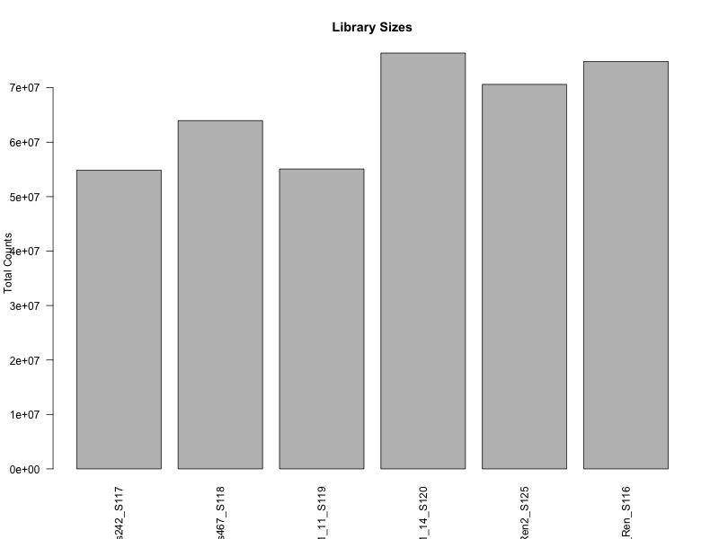

```r
knitr::include_graphics("/Users/yinuomeng/Desktop/Next_Gen_Seq/Individual_Project/Project_file_summary/Old_record_DESeq_images/barplot_dds_mT5_librarysize.png")
```

——Interpretation: the library sizes are not equal between samples, which suggest a difference in total read counts across all samples. So far, the data is not yet ready for quantification purpose. Need further normalization to make the data reliably quantifiable relatively to each other.

```r
# Before any further analysis: Remove genes with no reads
keep_genes <- rowSums(counts(dds_mT5)) > 0
dds_mT5 <- dds_mT5[ keep_genes, ]
```

#### Part VIII: SF-Adjustment and Normalization in DESeq analysis(Accessing DESeq analysis):

*Calculating and applying size factor:*

```r
dds_mT5 <- estimateSizeFactors(dds_mT5)      # calculate SFs, add them to object

# Plotting
png("/Users/yinuomeng/Desktop/Next_Gen_Seq/Individual_Project/Project_file_summary/Old_record_DESeq_images/SF_plot_mT5.png", width = 800, height = 600)
plot(sizeFactors(dds_mT5), colSums(counts(dds_mT5)), ylab = "library sizes", xlab = "size factors", cex = .6 )
dev.off()
```

Output of the size factor V.S. library size plot:

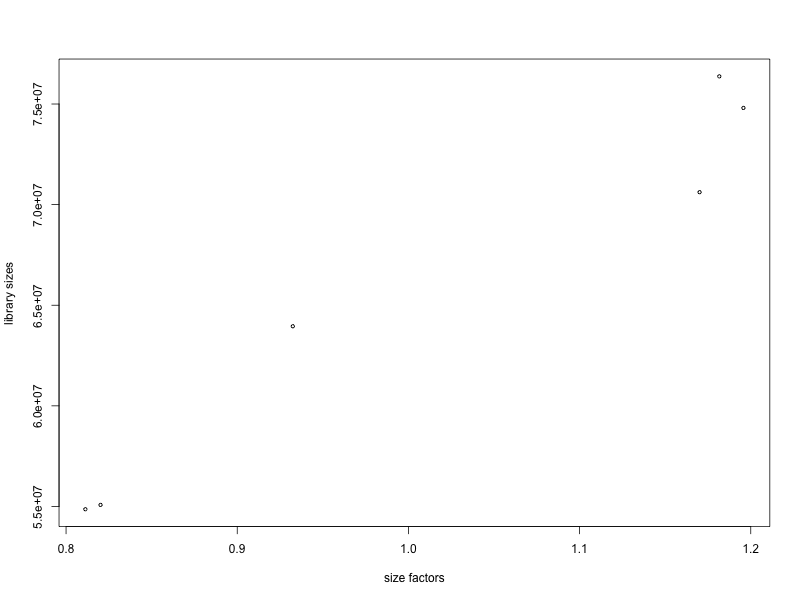

```r
knitr::include_graphics("/Users/yinuomeng/Desktop/Next_Gen_Seq/Individual_Project/Project_file_summary/Old_record_DESeq_images/SF_plot_mT5.png")
```

*Compare between raw read counts and SF normalized counts to assess whether normalization helped adjust gblobal differences between samples:*

```r
## extracting normalized counts
counts_sf_normalized <- counts(dds_mT5, normalized=TRUE)

## Plotting the boxplots
png("/Users/yinuomeng/Desktop/Next_Gen_Seq/Individual_Project/Project_file_summary/Old_record_DESeq_images/Rawread_mT5.png", width = 800, height = 600)
boxplot(counts(dds_mT5), main = "read counts only", cex = .6)
dev.off()

png("/Users/yinuomeng/Desktop/Next_Gen_Seq/Individual_Project/Project_file_summary/Old_record_DESeq_images/SFNorm_mT5.png", width = 800, height = 600)
boxplot(counts_sf_normalized, main = "SF normalized", cex = .6)
dev.off()
```

Output of the Raw read counts V.S. SF-normalized read counts plot:

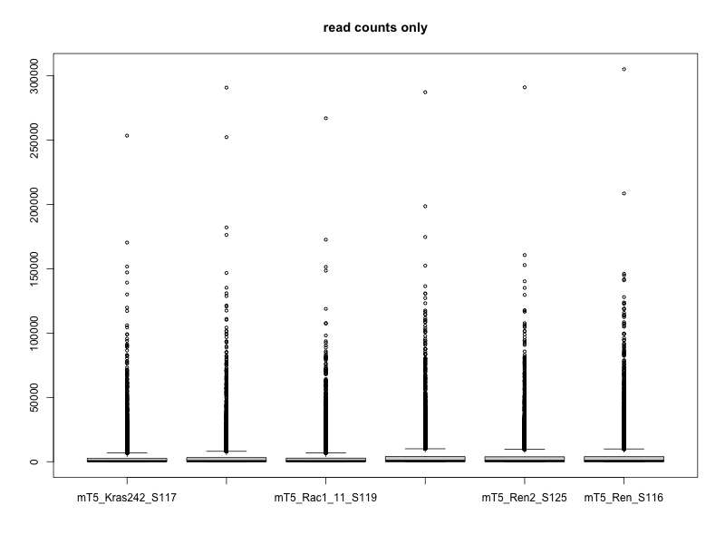

```r
knitr::include_graphics("/Users/yinuomeng/Desktop/Next_Gen_Seq/Individual_Project/Project_file_summary/Old_record_DESeq_images/Rawread_mT5.png")
```

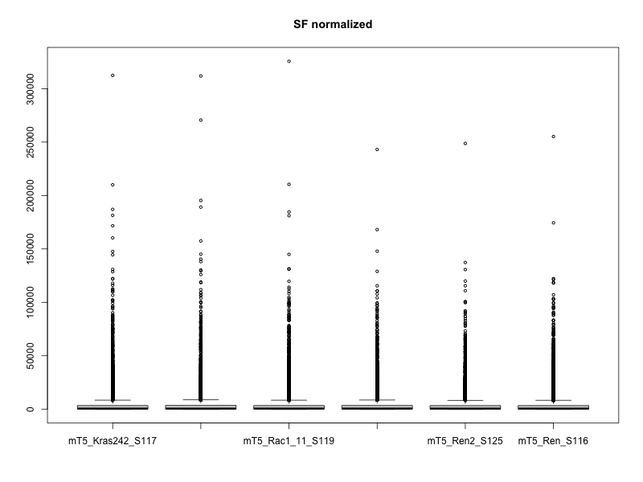

```r
knitr::include_graphics("/Users/yinuomeng/Desktop/Next_Gen_Seq/Individual_Project/Project_file_summary/Old_record_DESeq_images/SFNorm_mT5.png")
```

*To see the influence of the sequencing depth normalization more clearly, make box plots of log2(read counts):*

```r
# Plotting boxplot of non-normalized
png("/Users/yinuomeng/Desktop/Next_Gen_Seq/Individual_Project/Project_file_summary/Old_record_DESeq_images/Non-norm_mT5.png", width = 800, height = 600)
boxplot(log2(counts(dds_mT5) +1), notch=TRUE,
        main = "Non-normalized read counts",
        ylab ="log2(read counts)", cex = .6)
dev.off()

# Plotting boxplot of size-factor normalized values
png("/Users/yinuomeng/Desktop/Next_Gen_Seq/Individual_Project/Project_file_summary/Old_record_DESeq_images/Norm_mT5.png", width = 800, height = 600)
boxplot(log2(counts(dds_mT5, normalized=TRUE) +1), notch=TRUE,
        main = "Size-factor-normalized read counts",
        ylab ="log2(read counts)", cex = .6)
dev.off()
```

Output of the Raw read counts V.S. SF-normalized read counts plot in log2(read counts) forms:

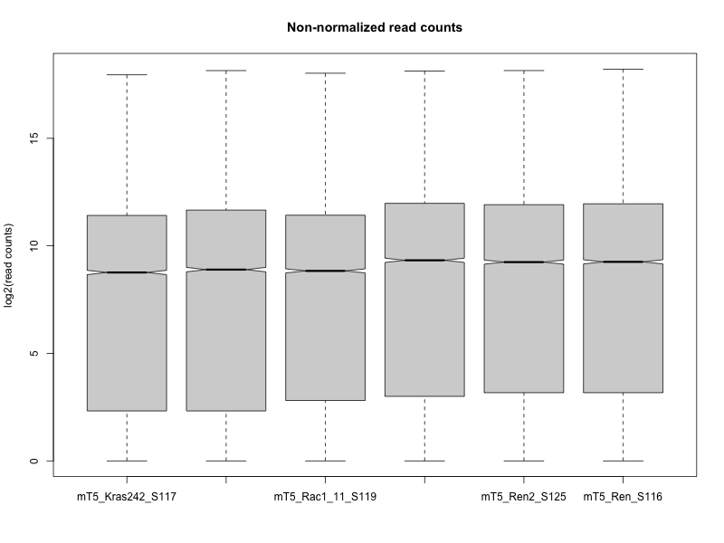

```r
knitr::include_graphics("/Users/yinuomeng/Desktop/Next_Gen_Seq/Individual_Project/Project_file_summary/Old_record_DESeq_images/Non-norm_mT5.png")
```

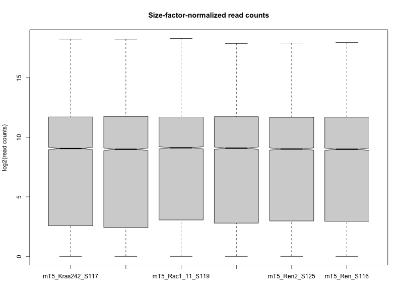

```r
knitr::include_graphics("/Users/yinuomeng/Desktop/Next_Gen_Seq/Individual_Project/Project_file_summary/Old_record_DESeq_images/Norm_mT5.png")
```

——Interpretation: Upon size factor normalization, the mean read counts of genes was aligned acrossed samples, making them quantitatively comparale ( more reliably ) for downstream analysis.

*Normalization(continued-rlog transformation): Make a scatterplot of log normalized counts against each other to see how well the actual values correlate which each other per sample and gene:*  
*This is to assess the variation between two biological samples representing one experimental condition and thus how well actual read count values can reflect real experimental manipulations.*

```r
# Get log counts and assign the log values to a distinct matrix within the DESeq.ds object
assay(dds_mT5, "log_counts") <- log2(counts(dds_mT5, normalized = FALSE) + 1)

# Normalize read counts
assay(dds_mT5, "log_norm_counts") <- log2(counts(dds_mT5, normalized=TRUE) + 1)
```

```r
# Generate correlation plots for each of the 3 experimental conditions in this analysis (Kras, Rac1, Ren)
png("/Users/yinuomeng/Desktop/Next_Gen_Seq/Individual_Project/Project_file_summary/Old_record_DESeq_images/KRAS_biolRepV_mT5.png", width = 800, height = 600)
dds_mT5[, c("mT5_Kras242_S117","mT5_Kras467_S118")] %>%
  assay(., "log_norm_counts") %>%
  plot(., cex=.1, main = "Kras242 vs. Kras467")
dev.off()

png("/Users/yinuomeng/Desktop/Next_Gen_Seq/Individual_Project/Project_file_summary/Old_record_DESeq_images/Rac1_biolRepV_mT5.png", width = 800, height = 600)
dds_mT5[, c("mT5_Rac1_11_S119","mT5_Rac1_14_S120")] %>%
  assay(., "log_norm_counts") %>%
  plot(., cex=.1, main = "Rac1_11 vs. Rac1_14")
dev.off()

png("/Users/yinuomeng/Desktop/Next_Gen_Seq/Individual_Project/Project_file_summary/Old_record_DESeq_images/Ren_biolRepV_mT5.png", width = 800, height = 600)
dds_mT5[, c("mT5_Ren2_S125","mT5_Ren_S116")] %>%
  assay(., "log_norm_counts") %>%
  plot(., cex=.1, main = "Ren2 vs. Ren")
dev.off()
```

Output of correlation plots for all 3 conditions:

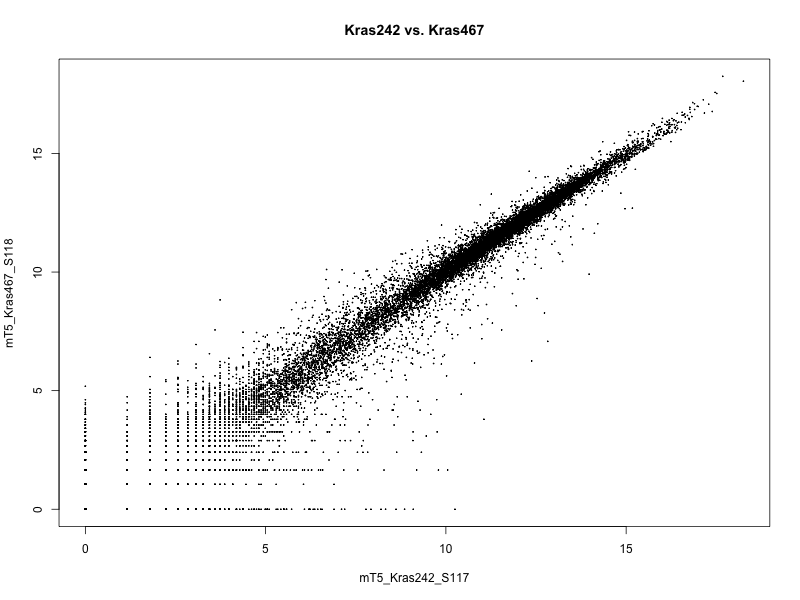

```r
knitr::include_graphics("/Users/yinuomeng/Desktop/Next_Gen_Seq/Individual_Project/Project_file_summary/Old_record_DESeq_images/Kras_biolRepV_mT5.png")
```

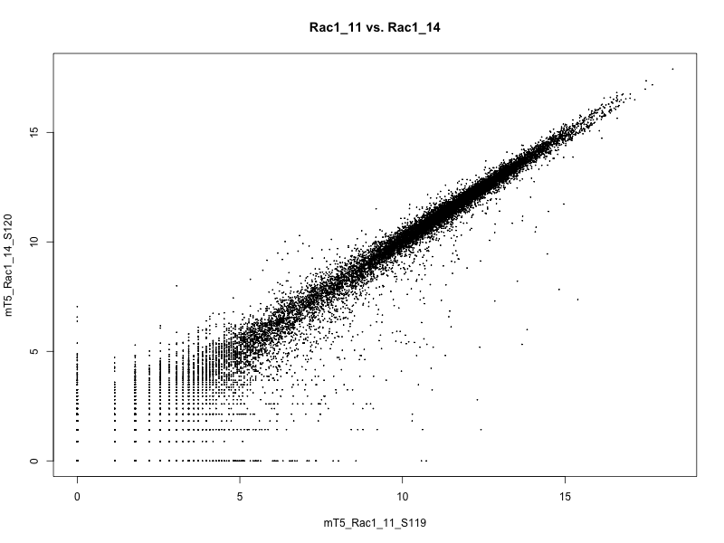

```r
knitr::include_graphics("/Users/yinuomeng/Desktop/Next_Gen_Seq/Individual_Project/Project_file_summary/Old_record_DESeq_images/Rac1_biolRepV_mT5.png")
```

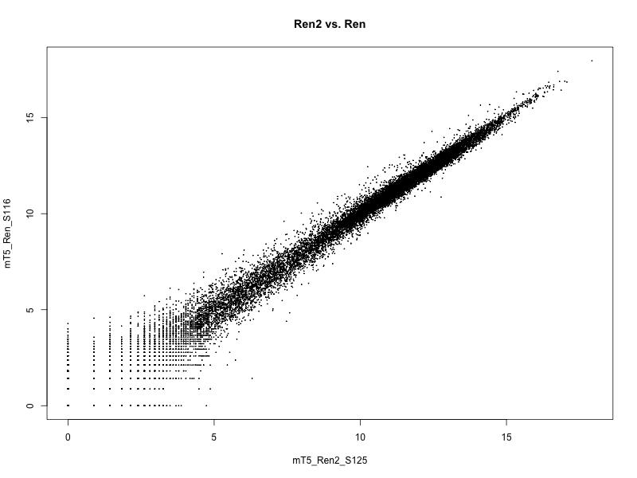

```r
knitr::include_graphics("/Users/yinuomeng/Desktop/Next_Gen_Seq/Individual_Project/Project_file_summary/Old_record_DESeq_images/Ren_biolRepV_mT5.png")
```

——Interpretation: This observation indicates that the standard deviation of the gene expression levels depends systematically on the mean: the lower the mean read counts per gene, the higher the standard deviation.

*Assess this pattern visually by vsn package functions:*

```r
# Generate the base meanSdPlot using sequencing depth normalized log2(read counts)

# Plotting
png("/Users/yinuomeng/Desktop/Next_Gen_Seq/Individual_Project/Project_file_summary/Old_record_DESeq_images/msdplot_mT5.png", width = 800, height = 600)
msd_plot <- vsn::meanSdPlot(assay(dds_mT5, "log_norm_counts"),
                            ranks=FALSE, # show the data on the original scale
                            plot = FALSE)
msd_plot$gg +
  ggtitle("Sequencing depth normalized log2(read counts)") +
  ylab("standard deviation")

dev.off()
```

Output msd plot:

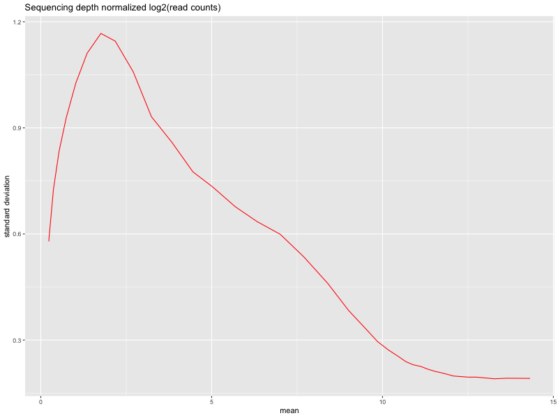

```r
knitr::include_graphics("/Users/yinuomeng/Desktop/Next_Gen_Seq/Individual_Project/Project_file_summary/Old_record_DESeq_images/msdplot_mT5.png")
```

*Reducing dependency of variance on the mean: (Use rlog)*

```r
ddsmT5_dst_rlog <- rlog(dds_mT5, blind = TRUE)
```

```r
# To visualize the results of rlog transformation:
# Cross compare log2 and rlog transformation differences:

# For log2 transformation:
png("/Users/yinuomeng/Desktop/Next_Gen_Seq/Individual_Project/Project_file_summary/Old_record_DESeq_images/SF_log2plot_mT5.png", width = 800, height = 600)

plot(assay(dds_mT5, "log_norm_counts")[,1:2], cex=.1, main = "size factor and log2-transformed")

dev.off()

# For rlog transformation
# (The rlog-transformed counts are stored in the "assay" accessor)
png("/Users/yinuomeng/Desktop/Next_Gen_Seq/Individual_Project/Project_file_summary/Old_record_DESeq_images/dst_rlog_mT5.png", width = 800, height = 600)

plot(assay(ddsmT5_dst_rlog)[,1:2],
     cex=.1, main = "rlog transformed",
     xlab = colnames(assay(ddsmT5_dst_rlog[,1])),
     ylab = colnames(assay(ddsmT5_dst_rlog[,2])) )

dev.off()
```

Output plots:

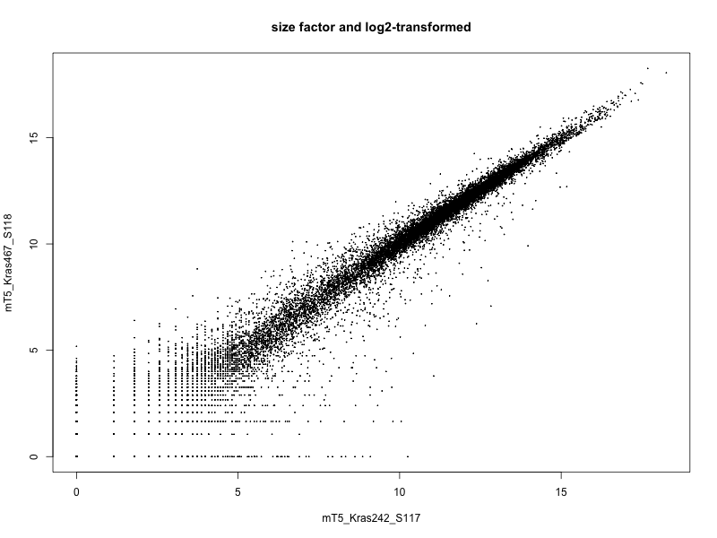

```r
knitr::include_graphics("/Users/yinuomeng/Desktop/Next_Gen_Seq/Individual_Project/Project_file_summary/Old_record_DESeq_images/SF_log2plot_mT5.png")
```

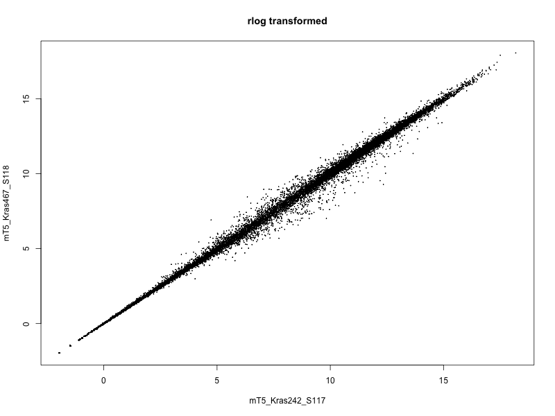

```r
knitr::include_graphics("/Users/yinuomeng/Desktop/Next_Gen_Seq/Individual_Project/Project_file_summary/Old_record_DESeq_images/dst_rlog_mT5.png")
```

——Interpretation: The variance much lower for small read counts using rlog.

```r
# To visualize the above interpretation: draw mean-sd-plot
png("/Users/yinuomeng/Desktop/Next_Gen_Seq/Individual_Project/Project_file_summary/Old_record_DESeq_images/msdplot_rlog_mT5.png", width = 800, height = 600)
msd_rlog_plot <- vsn::meanSdPlot(assay(ddsmT5_dst_rlog), ranks=FALSE, plot = FALSE)
msd_rlog_plot$gg + labs(title = "Following rlog transformation", x = "Mean", y = "Standard deviation") +
  coord_cartesian(ylim = c(0,3))
dev.off()
```

Output plot:

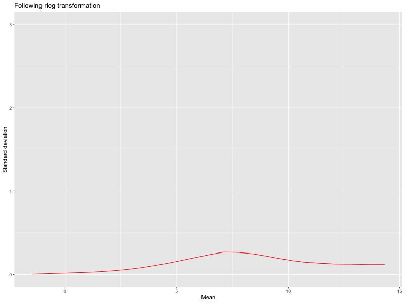

```r
knitr::include_graphics("/Users/yinuomeng/Desktop/Next_Gen_Seq/Individual_Project/Project_file_summary/Old_record_DESeq_images/msdplot_rlog_mT5.png")
```

——Interpretation: The variance dependency on mean at lower expression level genes was much reduced, though not perfect.

*Now save all images to R data for record-keeping purposes:*

```r
save.image(file = "/Users/yinuomeng/Desktop/Next_Gen_Seq/Individual_Project/Project_file_summary/Old_record_DESeq_images/mT5_DESeq_data-access_image.RData")
```